# IODS course project

Juho Pääkkönen

# Introduction to Open Data Science - Course Project

# 1. About the project

### What do I expect to learn on this course?

I expect to become more fluent with R tools and the data science workflow. This course seems to be a good place to get an all-around grasp of the basic ways of working with data science tools.

### My GitHub repository link

https://github.com/juhopaak/IODS-project

```r
date()
```

```
## [1] "Thu Nov 19 21:31:10 2020"
```

# 2. Regression and model validation

```r
date()
```

```
## [1] "Thu Nov 19 21:31:10 2020"
```

Let’s begin by reading the analysis dataset created in the data wrangling part, and exploring its structure and dimensions.

```r
data <- read.csv("data/learning2014.csv")
dim(data)
```

```
## [1] 166   7
```

```r
str(data)
```

```
## 'data.frame':    166 obs. of  7 variables:
##  $ gender  : Factor w/ 2 levels "F","M": 1 2 1 2 2 1 2 1 2 1 ...
##  $ age     : int  53 55 49 53 49 38 50 37 37 42 ...
##  $ attitude: num  3.7 3.1 2.5 3.5 3.7 3.8 3.5 2.9 3.8 2.1 ...
##  $ deep    : num  3.58 2.92 3.5 3.5 3.67 ...
##  $ stra    : num  3.38 2.75 3.62 3.12 3.62 ...
##  $ surf    : num  2.58 3.17 2.25 2.25 2.83 ...
##  $ points  : int  25 12 24 10 22 21 21 31 24 26 ...
```

The dataset has 166 observations and 7 variables. The variables are “gender”, “age”, “attitude”, “deep”, “stra”, “suft”, and “points”. The observations are student answers to the international survey of Approaches to Learning, on an introductory statistics course in 2014. The attitude variable is a score indicating the student’s attitude toward statistics, on scale 1-5. Thee deep, stra, and surf variables are average scores of answers to questions about different approaches to learning (deep learning, strategic learning, and surface learning), measured on the Likert scale. The points variable is an integer representing the student’s test score.

Let’s continue by looking at summaries of the variables and plotting the data.

```r
summary(data)
```

```
##  gender       age           attitude          deep            stra
##  F:110   Min.   :17.00   Min.   :1.400   Min.   :1.583   Min.   :1.250
##  M: 56   1st Qu.:21.00   1st Qu.:2.600   1st Qu.:3.333   1st Qu.:2.625
##          Median :22.00   Median :3.200   Median :3.667   Median :3.188
##          Mean   :25.51   Mean   :3.143   Mean   :3.680   Mean   :3.121
##          3rd Qu.:27.00   3rd Qu.:3.700   3rd Qu.:4.083   3rd Qu.:3.625
##          Max.   :55.00   Max.   :5.000   Max.   :4.917   Max.   :5.000
##       surf           points
##  Min.   :1.583   Min.   : 7.00
##  1st Qu.:2.417   1st Qu.:19.00
##  Median :2.833   Median :23.00
##  Mean   :2.787   Mean   :22.72
##  3rd Qu.:3.167   3rd Qu.:27.75
##  Max.   :4.333   Max.   :33.00
```

We can first see that the student gender distribution includes almost twice the number of females in comparison to males.

The youngest students were 17 years old and the oldest 55 years. The 3rd quartile of age is 27, which means that most of the students are between 17-27 years old. We can also see this in the variable’s histogram plot.

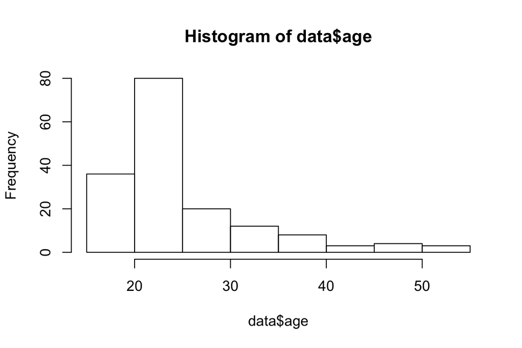

```r
hist(data$age)
```

The attitude variable is distributed between 1.4 and 5, with half of the answers between 2.6 and 3.7. This variable’s distribution resembles the normal distribution, as displayed below.

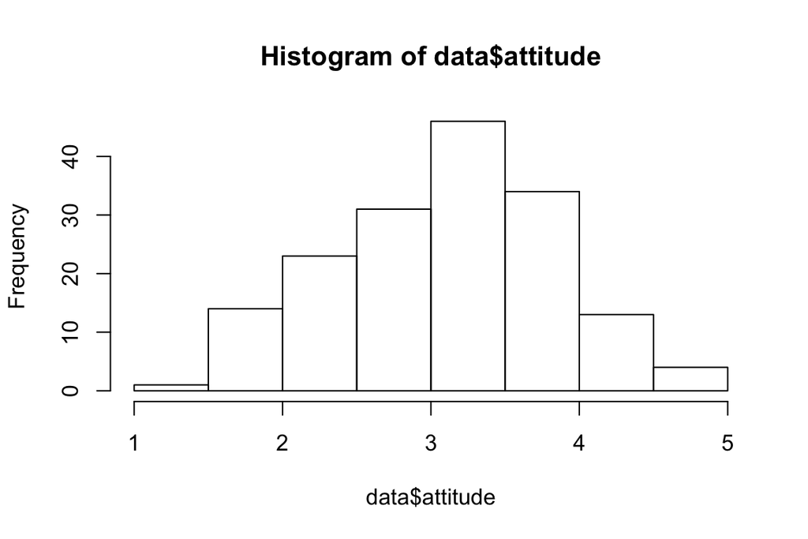

```r
hist(data$attitude)
```

The deep variable is distributed between 1.583 and 4.917, but the 1st quartile is 3.333, so most of the answers were between 3.333 and 4.917. In the stra variable we see a more even distribution between 1.250 and 5, but still the 1st quartile is 2.625, so most of the values are clustered between 2.625 and 3.625. The surf variable, on the other hand, seems to be somewhat skewed towards lower values, with distribution between 1.583 and 4.333 but the 1st quartile at 2.417. The histograms below confirm these observations.

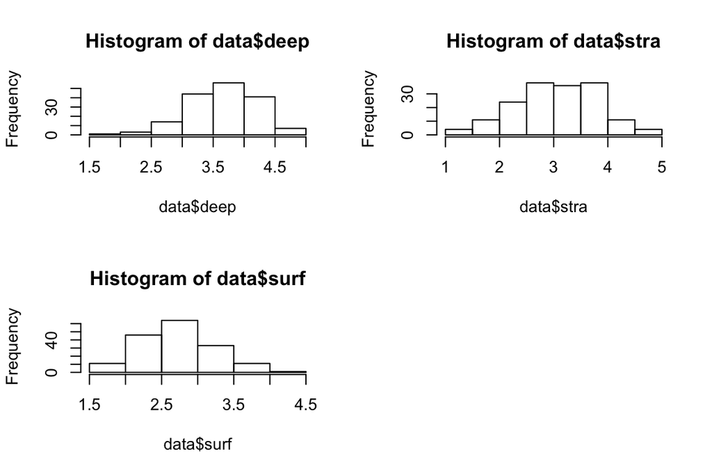

```r
par(mfrow =c(2,2))
hist(data$deep)
hist(data$stra)
hist(data$surf)
```

The test points are distributed between 7 and 33, but the 1st quartile is 19, the median 23 and the 3rd quartile 27.75. It seems that the scores are distributed quite evenly between 19 and 27.75. Most of the scores seem to be between 15 and 30, as shown below.

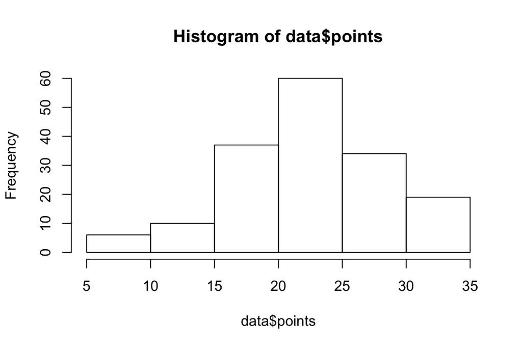

```r
hist(data$points)
```

Let’s next look at a scatter diagram of the data, which displays the relationships between the different variables.

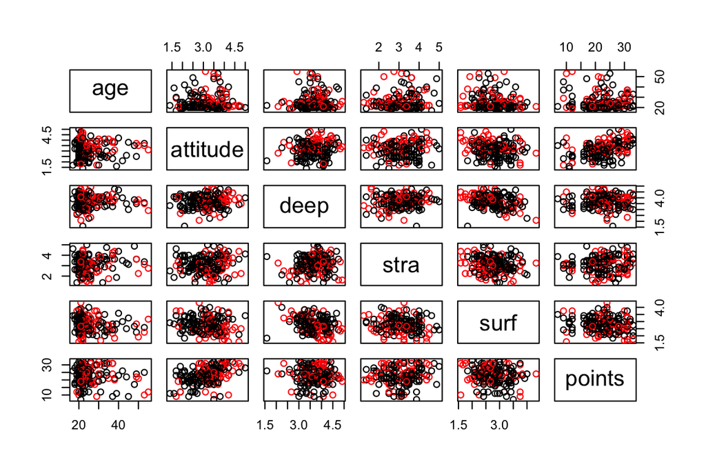

```r
pairs(data[-1], col=data$gender)
```

From inspecting the scatter diagram it seems that the variables most strongly correlated with points are attitude, stra, and surf. Let’s try these three as explanatory variables in the linear model.

```r
model <- lm(points ~ attitude+stra+surf, data = data)
summary(model)
```

```
##
## Call:
## lm(formula = points ~ attitude + stra + surf, data = data)
##
## Residuals:
##      Min       1Q   Median       3Q      Max
## -17.1550  -3.4346   0.5156   3.6401  10.8952
##
## Coefficients:
##             Estimate Std. Error t value Pr(>|t|)
## (Intercept)  11.0171     3.6837   2.991  0.00322 **
## attitude      3.3952     0.5741   5.913 1.93e-08 ***
## stra          0.8531     0.5416   1.575  0.11716
## surf         -0.5861     0.8014  -0.731  0.46563
## ---
## Signif. codes:  0 '***' 0.001 '**' 0.01 '*' 0.05 '.' 0.1 ' ' 1
##
## Residual standard error: 5.296 on 162 degrees of freedom
## Multiple R-squared:  0.2074, Adjusted R-squared:  0.1927
## F-statistic: 14.13 on 3 and 162 DF,  p-value: 3.156e-08
```

From the coefficient estimates of different parameters we can see that attitude predicts the value of points with the effect of 3.3952, whereas stra and surf with 0.8531 and -0.5861 respectively. This means that value changes in the attitude parameter are more strongly associated with changes in the value of points. In fact, stra and surf are quite weakly associated with points, which is also reflected in their p-scores, which indicate that these variables do not have a significant relationship (<0.05) to the points variable. A large p-score means that the probability of observing at least as extreme values of the target variable is be high, even though the coefficients were not related to the target variable. The p-values of stra and surf mean that we have no strong evidence on the basis of the data to reject the null hypothesis that stra and surf have no effect on the values of the points variable.

Let’s fit the model again with just the attitude as explanatory variable.

```r
model <- lm(points ~ attitude, data = data)
summary(model)
```

```
##
## Call:
## lm(formula = points ~ attitude, data = data)
##
## Residuals:
##      Min       1Q   Median       3Q      Max
## -16.9763  -3.2119   0.4339   4.1534  10.6645
##
## Coefficients:
##             Estimate Std. Error t value Pr(>|t|)
## (Intercept)  11.6372     1.8303   6.358 1.95e-09 ***
## attitude      3.5255     0.5674   6.214 4.12e-09 ***
## ---
## Signif. codes:  0 '***' 0.001 '**' 0.01 '*' 0.05 '.' 0.1 ' ' 1
##
## Residual standard error: 5.32 on 164 degrees of freedom
## Multiple R-squared:  0.1906, Adjusted R-squared:  0.1856
## F-statistic: 38.61 on 1 and 164 DF,  p-value: 4.119e-09
```

In this model, the coefficient estimates show that attitude predicts the value of points with the effect of 3.5255, which is slightly stronger than in the previous model. Also the standard error of the coefficient is slightly smaller, and the p-value is notably smaller. The results show that attitude is a highly significant predictor of points.

The multiple R-squared gives the proportion of variation in the target variable points that is explained by the regression coefficients, that is, attitude. We can see that attitude alone explains around 19% of the variation in the points variable.

Finally, let’s examine diagnostic plots of the model.

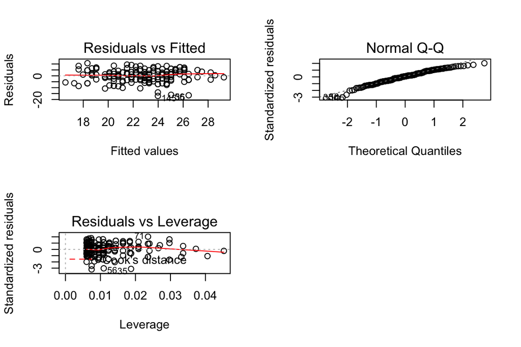

```r
par(mfrow =c(2,2))
plot(model, which=c(1,2,5))
```

The model is based on four important assumptions: linearity, constant variance, normality of residuals, and that the model’s errors are independent. The plots above can be used to examine the validity of the latter three.

1. The constant variance assumption holds that the size of the model’s errors should not depend on the explanatory variable. This assumption can be validated by plotting the residuals (model errors) against fitted values. The assumption is validated if the resulting scatterplot is reasonably evenly distributed. Indeed, we can see from the residuals vs. fitted values plot above that this is the case.
2. The normality assumption holds that the model’s errors are normally distributed. This assumption can be validated by plotting the residuals against values drawn from the normal distribution. If these values fall roughly along the diagonal line in the Normal Q-Q plot, then the model’s errors are approximately normally distributed.
3. The residuals vs. leverage plot helps assess whether there are some observations that have a large influence on the estimation of the model’s parameters. If there are some observations that have high leverage, then excluding them from the analysis has a large influence on the model. In the plot, if some points fall within areas delimited by the red dashed line (Cook’s distance), then they correspond to influential observations. It seems that in this model there are no highly influential residuals.

Together from these plots we can see that the model’s assumptions seem to be valid.

# 3. Logistic regression

```r
date()
```

```
## [1] "Thu Nov 19 21:31:11 2020"
```

Let’s begin by reading the joined dataset from local directory.

```r
data <- read.csv("data/alc.csv")
dim(data)
```

```
## [1] 382  35
```

As displayed above, the data includes 382 observations and 35 variables. The data are about student achievement in secondary education of two Portuguese schools, collected by using school reports and questionnaires. The data used in this analysis is a combination of two datasets from distinct subjects: Mathematics and Portuguese language. The dataset includes the following variables.

```r
colnames(data)
```

```
##  [1] "school"     "sex"        "age"        "address"    "famsize"
##  [6] "Pstatus"    "Medu"       "Fedu"       "Mjob"       "Fjob"
## [11] "reason"     "nursery"    "internet"   "guardian"   "traveltime"
## [16] "studytime"  "failures"   "schoolsup"  "famsup"     "paid"
## [21] "activities" "higher"     "romantic"   "famrel"     "freetime"
## [26] "goout"      "Dalc"       "Walc"       "health"     "absences"
## [31] "G1"         "G2"         "G3"         "alc_use"    "high_use"
```

In this analysis we will study the relationship between high/low alchohol consumption of the students (the variable “high_use”), and four other variables in the data. As the four explanatory variables, let’s select

1. The student’s age (variable “age”)
2. Weekly study time (variable “studytime”)
3. The number of past class failures (variable “failures”)
4. The quality of family relationships (variable “famrel”)

My personal hypothesis is that all these variables will be significantly related to the students’ volume of alcohol consumption. In particular, I expect that (1) the older the student and the more time they use for studying, the less likely they are to consume high volumes of alcohol; and (2) students who have had many class failures and have a low quality of family relationships are more likely to consume a lot of alcohol.

Let’s next explore the distributions of these four variables and their relationship with alcohol consumption.

Let’s first look at bar charts of the four explanatory variables.

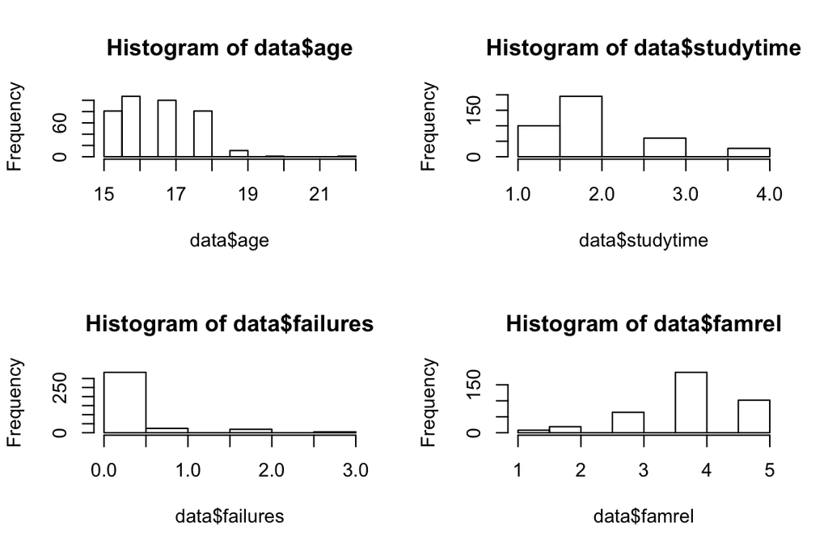

```r
par(mfrow =c(2,2))
hist(data$age)
hist(data$studytime)
hist(data$failures)
hist(data$famrel)
```

It seems that most of the students are between ages 15-18, and that most of them use less than 5 hours a week for studying. Further, most of them have had no class failures, and their family relations are generally very good.

If we then look at the summary and a boxplot of the students’ alcohol use, we see that the means of their answers to daily and weekend alcohol use are distributed between 1 and 5, but the majority of answers are between 1 and 2.5. In fact, it seems that the mean score of 5 is an outlier, as we can see from the boxplot.

```r
summary(data$alc_use)
```

```
##    Min. 1st Qu.  Median    Mean 3rd Qu.    Max.
##   1.000   1.000   1.500   1.889   2.500   5.000
```

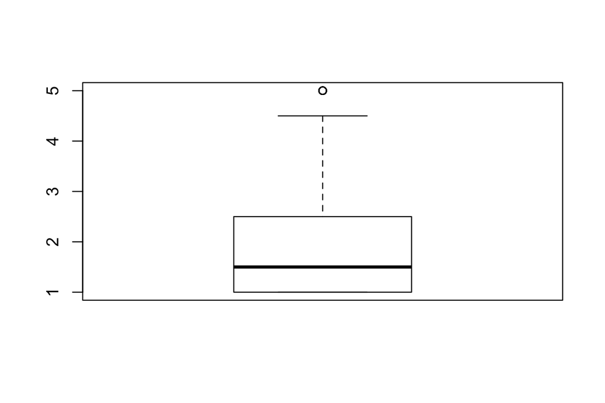

```r
boxplot(data$alc_use)
```

If we then look at cross-tabulations of the four explanatory variables and the logical variable representing high/low alcohol use, we see that my initial hypotheses will not be very likely to hold, at least without qualification.

First, from the table of age against alcohol use, we see that the highest ratios of high alcohol use in comparison to low alcohol use are in the age groups of over 16. This means that the older students consume more alcohol than the younger students, contrary to what I expected.

```r
table(data$age, data$high_use)
```

```
##
##      FALSE TRUE
##   15    63   18
##   16    79   28
##   17    64   36
##   18    54   27
##   19     7    4
##   20     1    0
##   22     0    1
```

From the table of study time against alcohol use, we see that indeed students who study less than 5 hours a week seem to consume more alcohol than those who study more.

```r
table(data$studytime, data$high_use)
```

```
##
##     FALSE TRUE
##   1    58   42
##   2   135   60
##   3    52    8
##   4    23    4
```

However, when tabulating past failures against alcohol use, we see that most of the students who have high alcohol consumption have no past failures. This is likely due to the fact that so few students in the data have past failures in the first place.

```r
table(data$failures, data$high_use)
```

```
##
##     FALSE TRUE
##   0   244   90
##   1    12   12
##   2    10    9
##   3     2    3
```

Finally, from the table of family relations against alcohol use, we see that most of the students with high alcohol consumption have good family relations - again likely due to most of the students in the data having good relations.

```r
table(data$famrel, data$high_use)
```

```
##
##     FALSE TRUE
##   1     6    2
##   2    10    9
##   3    39   25
##   4   135   54
##   5    78   24
```

Let’s now explore the relationship between these variables using logistic regression. The call glm() below fits the model to the alc data. The summary of the model is given after.

```r
model <- glm(high_use ~ age + studytime + failures + famrel, data = data, family = "binomial")
summary(model)
```

```
##
## Call:
## glm(formula = high_use ~ age + studytime + failures + famrel,
##     family = "binomial", data = data)
##
## Deviance Residuals:
##     Min       1Q   Median       3Q      Max
## -1.4449  -0.8466  -0.6790   1.2448   2.2240
##
## Coefficients:
##             Estimate Std. Error z value Pr(>|z|)
## (Intercept)  -2.1233     1.7523  -1.212 0.225624
## age           0.1961     0.1023   1.916 0.055335 .
## studytime    -0.5466     0.1584  -3.451 0.000559 ***
## failures      0.2855     0.1928   1.480 0.138767
## famrel       -0.2541     0.1265  -2.009 0.044537 *
## ---
## Signif. codes:  0 '***' 0.001 '**' 0.01 '*' 0.05 '.' 0.1 ' ' 1
##
## (Dispersion parameter for binomial family taken to be 1)
##
##     Null deviance: 465.68  on 381  degrees of freedom
## Residual deviance: 436.65  on 377  degrees of freedom
## AIC: 446.65
##
## Number of Fisher Scoring iterations: 4
```

From the results we can see that two variables in the model are significant predictors of high alcohol use, namely studytime and famrel. Of these, studytime is a highly significant predictor. The sign of the estimates of the coefficients of both these variables are negative. This means that students who study more are less likely to consume high volumes of alcohol, and similarly students who have good family relations are less likely to drink high volumes. Each increase in studytime will decrease the log odds of having high alcohol consumption by 0.5466, and each increase in family relations will decrease the odds by 0.2541.

The results also show that there is no strong evidence for rejecting the null hypothesis that the students’ age and past class failures are related to their high/low alcohol consumption.

Let’s now compute the odds ratios (OR in the below table) of the model coefficients, and provide confidence intervals for them.

```r
# Odds ratios (OR) from model coefficients
OR <- exp(coef(model))

# Confidence intervals (CI)
CI <- exp(confint(model))
# Tabulate results
cbind(OR, CI)
```

```
##                    OR       2.5 %    97.5 %
## (Intercept) 0.1196357 0.003741489 3.6605851
## age         1.2166121 0.997143320 1.4906891
## studytime   0.5789116 0.420249609 0.7831056
## failures    1.3303606 0.911465723 1.9525463
## famrel      0.7756136 0.604403440 0.9941132
```

The coefficient of studytime has odds ratio of ~0.58, which means that students who study more are almost twice as likely to not have high alcohol consumption than students who study less. In the case of famrel, the odds ratio is ~0.78, which means that family relations are not as strongly associated with high consumption as study time. But still students who have good family relations are more likely to have low alcohol consumption than students with good relations. We can also see that student age and past failures are positively related to alcohol consumption, but these variables did not have a significant relationship in the model, so we cannot take this as evidence that there actually exists a relationship in the data.

The confidence intervals give the range of values within which the strength of the relationships between the variables are likely to fall with 95% confidence. So of 100 times that we calculate a confidence interval for e.g. the strenght of the relationship between studytime and high/low alcohol use, 95 times of these the true value will be within the specified range.

For the coefficient estimate of studytime, the 95% confidence interval is (0.42, 0.78), and for famrel (0.60, 0.99). Both of these ranges preserve the direction of the relationship. However, for instance for the failures variable, the interval is (0.91, 1.95). First, this is quite wide, and second we cannot say with 95% for this variable whether having many failures has a positive or negative influence on the log odds of having high alcohol consumption. We can see that the same is true of the age variable, although the interval is not as wide.

These results contradict my initial hypotheses in that age and past failures were not significantly related to high alcohol consumption. Study time and family relations, however, were significantly related, as I expected. Further, study time was a highly significant predictor.

Let’s now evaluate the predictive power of these significant explanatory variables. Let’s start by fitting a model with just these two variables.

```r
model <- glm(high_use ~ studytime + famrel, data = data, family = "binomial")
summary(model)
```

```
##
## Call:
## glm(formula = high_use ~ studytime + famrel, family = "binomial",
##     data = data)
##
## Deviance Residuals:
##     Min       1Q   Median       3Q      Max
## -1.3749  -0.8225  -0.7364   1.3140   2.1048
##
## Coefficients:
##             Estimate Std. Error z value Pr(>|z|)
## (Intercept)   1.3041     0.5700   2.288 0.022139 *
## studytime    -0.5946     0.1529  -3.888 0.000101 ***
## famrel       -0.2563     0.1243  -2.062 0.039207 *
## ---
## Signif. codes:  0 '***' 0.001 '**' 0.01 '*' 0.05 '.' 0.1 ' ' 1
##
## (Dispersion parameter for binomial family taken to be 1)
##
##     Null deviance: 465.68  on 381  degrees of freedom
## Residual deviance: 444.08  on 379  degrees of freedom
## AIC: 450.08
##
## Number of Fisher Scoring iterations: 4
```

In this model, studytime seems to have an even stronger relationship with alcohol use, while the relationship between famrel and alcohol use remained nearly the same.

Let’s now predict the probability of high_use using this model, and tabulate the results.

```r
library(tidyverse)
probabilities <- predict(model, type = "response")

# add the predicted probabilities to data
data <- mutate(data, probability = probabilities)

# use the probabilities to make a prediction of high_use
data <- mutate(data, prediction = probability > 0.5)

# tabulate the target variable versus the predictions
table(high_use = data$high_use, prediction = data$prediction)
```

```
##         prediction
## high_use FALSE TRUE
##    FALSE   265    3
##    TRUE    109    5
```

From the confusion matrix we can see that the model correctly predicts 265 out of 268 cases of low alcohol, but incorrectly predicts that 109 cases of high alcohol use would have low use. Only 5 out of the total of 114 cases of high use were predicted correctly. Let’s compute the training error to see how the model fares overall.

The following code defines mean prediction error as the loss function and calculates for the model’s predictions.

```r
loss_func <- function(class, prob) {
  n_wrong <- abs(class - prob) > 0.5
  mean(n_wrong)
}

loss_func(class = data$high_use, prob = data$probability)
```

```
## [1] 0.2931937
```

The mean prediction error is 0.2931937, which means that the model correctly predicts high/low alcohol consumption in over 70% of the cases in the data.

To end this exercise, let’s still do 10-fold cross-validation and compare the results with the model introduced in DataCamp (with error of 0.2617801).

```r
# We'll use the package boot for performing cross-validation
library(boot)

# K=10 means 10 folds
cv <- cv.glm(data = data, cost = loss_func, glmfit = model, K = 10)

# average number of wrong predictions in the cross validation
cv$delta[1]
```

```
## [1] 0.2958115
```

My model has higher average error with 10-fold cv than the DataCamp model. Better than flipping a coin, though.

# 4. Clustering and classification

```r
date()
```

```
## [1] "Thu Nov 19 21:31:13 2020"
```

Let’s load the Boston data and explore its dimensions. The dataset contains information collected by the U.S. Census Service, about housing in the Boston area.

```r
library(MASS)
data("Boston")

str(Boston)
```

```
## 'data.frame':    506 obs. of  14 variables:
##  $ crim   : num  0.00632 0.02731 0.02729 0.03237 0.06905 ...
##  $ zn     : num  18 0 0 0 0 0 12.5 12.5 12.5 12.5 ...
##  $ indus  : num  2.31 7.07 7.07 2.18 2.18 2.18 7.87 7.87 7.87 7.87 ...
##  $ chas   : int  0 0 0 0 0 0 0 0 0 0 ...
##  $ nox    : num  0.538 0.469 0.469 0.458 0.458 0.458 0.524 0.524 0.524 0.524 ...
##  $ rm     : num  6.58 6.42 7.18 7 7.15 ...
##  $ age    : num  65.2 78.9 61.1 45.8 54.2 58.7 66.6 96.1 100 85.9 ...
##  $ dis    : num  4.09 4.97 4.97 6.06 6.06 ...
##  $ rad    : int  1 2 2 3 3 3 5 5 5 5 ...
##  $ tax    : num  296 242 242 222 222 222 311 311 311 311 ...
##  $ ptratio: num  15.3 17.8 17.8 18.7 18.7 18.7 15.2 15.2 15.2 15.2 ...
##  $ black  : num  397 397 393 395 397 ...
##  $ lstat  : num  4.98 9.14 4.03 2.94 5.33 ...
##  $ medv   : num  24 21.6 34.7 33.4 36.2 28.7 22.9 27.1 16.5 18.9 ...
```

```r
dim(Boston)
```

```
## [1] 506  14
```

The dataset has 506 observations and 14 variables. All the variables are numeric, and they are about phenomena such as crime rate per capita by town (crim), proportion of non-retail business acres per town (indus), and average number of rooms per dwelling (rm).

Let’s now summarize the variables in the data, and then look at a graphical overview of them.

```r
summary(Boston)
```

```
##       crim                zn             indus            chas
##  Min.   : 0.00632   Min.   :  0.00   Min.   : 0.46   Min.   :0.00000
##  1st Qu.: 0.08204   1st Qu.:  0.00   1st Qu.: 5.19   1st Qu.:0.00000
##  Median : 0.25651   Median :  0.00   Median : 9.69   Median :0.00000
##  Mean   : 3.61352   Mean   : 11.36   Mean   :11.14   Mean   :0.06917
##  3rd Qu.: 3.67708   3rd Qu.: 12.50   3rd Qu.:18.10   3rd Qu.:0.00000
##  Max.   :88.97620   Max.   :100.00   Max.   :27.74   Max.   :1.00000
##       nox               rm             age              dis
##  Min.   :0.3850   Min.   :3.561   Min.   :  2.90   Min.   : 1.130
##  1st Qu.:0.4490   1st Qu.:5.886   1st Qu.: 45.02   1st Qu.: 2.100
##  Median :0.5380   Median :6.208   Median : 77.50   Median : 3.207
##  Mean   :0.5547   Mean   :6.285   Mean   : 68.57   Mean   : 3.795
##  3rd Qu.:0.6240   3rd Qu.:6.623   3rd Qu.: 94.08   3rd Qu.: 5.188
##  Max.   :0.8710   Max.   :8.780   Max.   :100.00   Max.   :12.127
##       rad              tax           ptratio          black
##  Min.   : 1.000   Min.   :187.0   Min.   :12.60   Min.   :  0.32
##  1st Qu.: 4.000   1st Qu.:279.0   1st Qu.:17.40   1st Qu.:375.38
##  Median : 5.000   Median :330.0   Median :19.05   Median :391.44
##  Mean   : 9.549   Mean   :408.2   Mean   :18.46   Mean   :356.67
##  3rd Qu.:24.000   3rd Qu.:666.0   3rd Qu.:20.20   3rd Qu.:396.23
##  Max.   :24.000   Max.   :711.0   Max.   :22.00   Max.   :396.90
##      lstat            medv
##  Min.   : 1.73   Min.   : 5.00
##  1st Qu.: 6.95   1st Qu.:17.02
##  Median :11.36   Median :21.20
##  Mean   :12.65   Mean   :22.53
##  3rd Qu.:16.95   3rd Qu.:25.00
##  Max.   :37.97   Max.   :50.00
```

Let’s now look at a graphical overview of the variables.

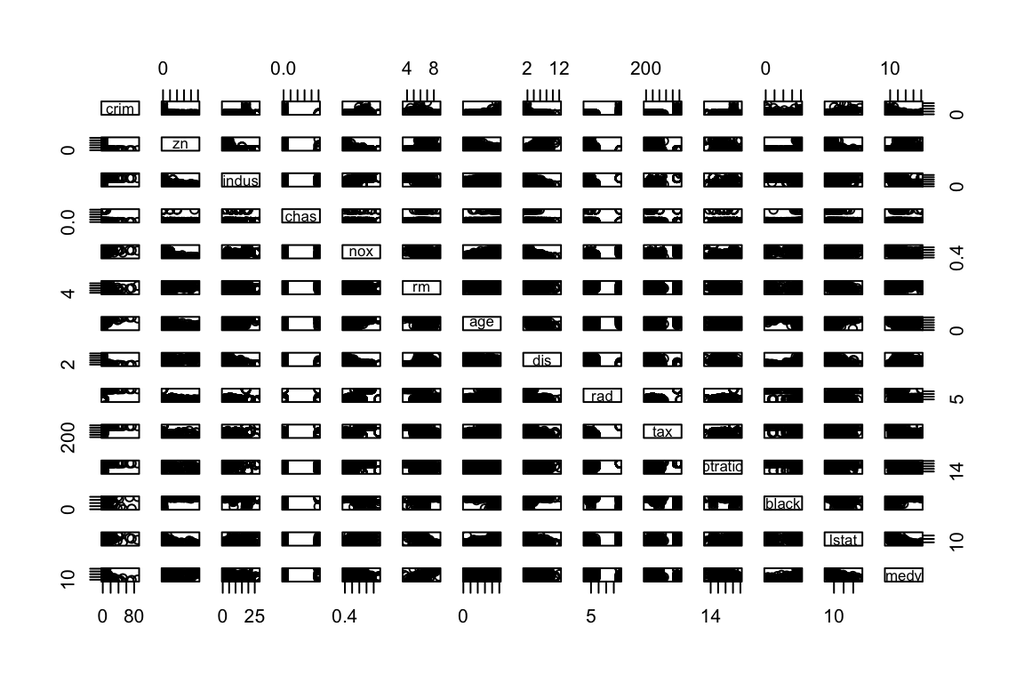

```r
pairs(Boston)
```

It’s pretty hard to get a good overview of so many variables at a glance, so we’d need to do more detailed examinations of the relationships between them. Let’s use the correlation plot to first look at the relationships between all the variables, and then get a better look at the most interesting ones.

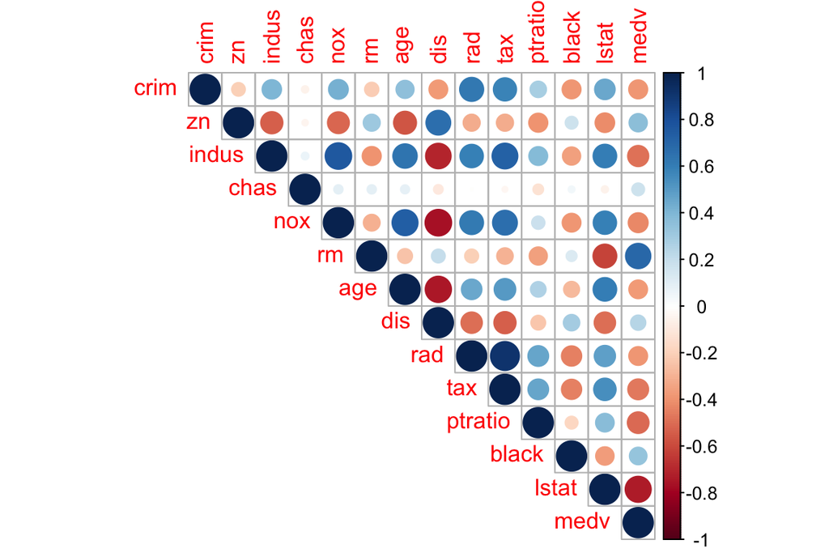

```r
library(corrplot)
cor_matrix <- cor(Boston)
corrplot(cor_matrix, method="circle", type="upper")
```

It seems that crim is positively correlated with rad and tax, whereas the indus variable is positively correlated with nox and tax, but negatively correlated with dis. Let’s plot these variables against each other.

We’ll begin with crim, rad and tax, which measure crime rate per capita by town, index of accessibility to radial highways, and full-value property tax rate per $10,000, respectively

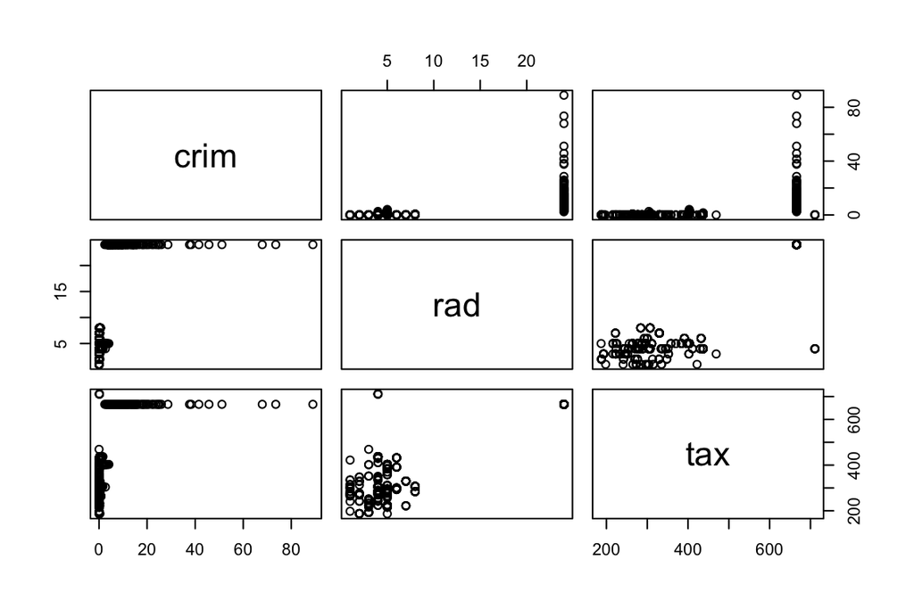

```r
pairs(~crim+rad+tax,data=Boston)
```

High values of both rad and tax seem to also bring crime rate up, but there’s a break in the relationship in mid values of these variables. Let’s next look at the indus variable against nox, tax and dis. These variables measure the proportion of non-retail business acres per town (indus), nitric oxides concentration (nox), property tax, and the distance to five Boston employment centres (dis).

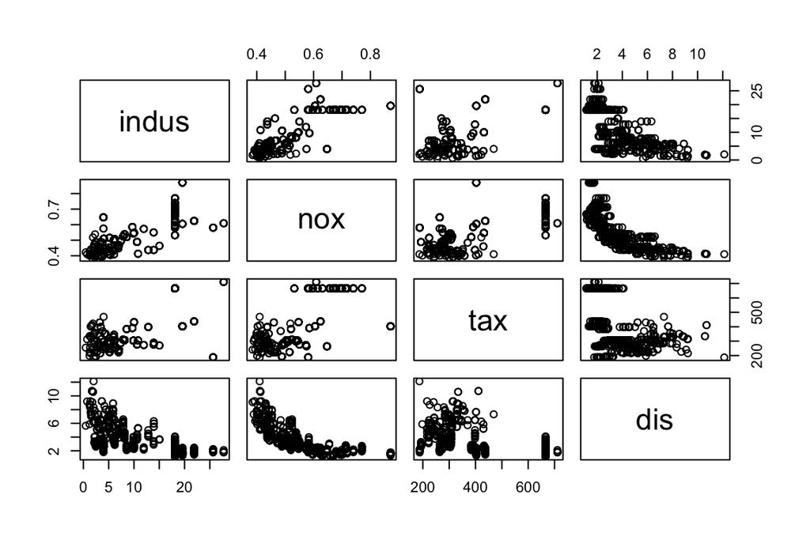

```r
pairs(~indus+nox+tax+dis, data=Boston)
```

Interestingly, the proportion of non-retail business acres per town indeed seems to grow with nitric oxides concentration. The positive relationship seems to be less clear with property tax, while the negative relationshipn with distance to Boston employment centres seems quite strong.

Let’s now standardize the dataset and create a categorical variable of crime rate per quantiles in order to predict it using linear discriminant analysis (LDA).

We’ll begin by scaling and summarizing the data again.

```r
boston_scaled <- scale(Boston)
summary(boston_scaled)
```

```
##       crim                 zn               indus              chas
##  Min.   :-0.419367   Min.   :-0.48724   Min.   :-1.5563   Min.   :-0.2723
##  1st Qu.:-0.410563   1st Qu.:-0.48724   1st Qu.:-0.8668   1st Qu.:-0.2723
##  Median :-0.390280   Median :-0.48724   Median :-0.2109   Median :-0.2723
##  Mean   : 0.000000   Mean   : 0.00000   Mean   : 0.0000   Mean   : 0.0000
##  3rd Qu.: 0.007389   3rd Qu.: 0.04872   3rd Qu.: 1.0150   3rd Qu.:-0.2723
##  Max.   : 9.924110   Max.   : 3.80047   Max.   : 2.4202   Max.   : 3.6648
##       nox                rm               age               dis
##  Min.   :-1.4644   Min.   :-3.8764   Min.   :-2.3331   Min.   :-1.2658
##  1st Qu.:-0.9121   1st Qu.:-0.5681   1st Qu.:-0.8366   1st Qu.:-0.8049
##  Median :-0.1441   Median :-0.1084   Median : 0.3171   Median :-0.2790
##  Mean   : 0.0000   Mean   : 0.0000   Mean   : 0.0000   Mean   : 0.0000
##  3rd Qu.: 0.5981   3rd Qu.: 0.4823   3rd Qu.: 0.9059   3rd Qu.: 0.6617
##  Max.   : 2.7296   Max.   : 3.5515   Max.   : 1.1164   Max.   : 3.9566
##       rad               tax             ptratio            black
##  Min.   :-0.9819   Min.   :-1.3127   Min.   :-2.7047   Min.   :-3.9033
##  1st Qu.:-0.6373   1st Qu.:-0.7668   1st Qu.:-0.4876   1st Qu.: 0.2049
##  Median :-0.5225   Median :-0.4642   Median : 0.2746   Median : 0.3808
##  Mean   : 0.0000   Mean   : 0.0000   Mean   : 0.0000   Mean   : 0.0000
##  3rd Qu.: 1.6596   3rd Qu.: 1.5294   3rd Qu.: 0.8058   3rd Qu.: 0.4332
##  Max.   : 1.6596   Max.   : 1.7964   Max.   : 1.6372   Max.   : 0.4406
##      lstat              medv
##  Min.   :-1.5296   Min.   :-1.9063
##  1st Qu.:-0.7986   1st Qu.:-0.5989
##  Median :-0.1811   Median :-0.1449
##  Mean   : 0.0000   Mean   : 0.0000
##  3rd Qu.: 0.6024   3rd Qu.: 0.2683
##  Max.   : 3.5453   Max.   : 2.9865
```

The variables now have zero means and their values have been normalized in relation to the original data’s standard deviation. This means that the value distributions now tell us how much each variable varies around their means in relation to the standard deviation, which makes their values comparable against each other. For instance, the max value in the crim variable now is at 9.924110, while the max of the tax variable is only at 1.7964. The positive values of the tax variable seem to be closer to the variable’s mean, so it has fewer outliers than crim. This we can also see from the boxplots of these variables

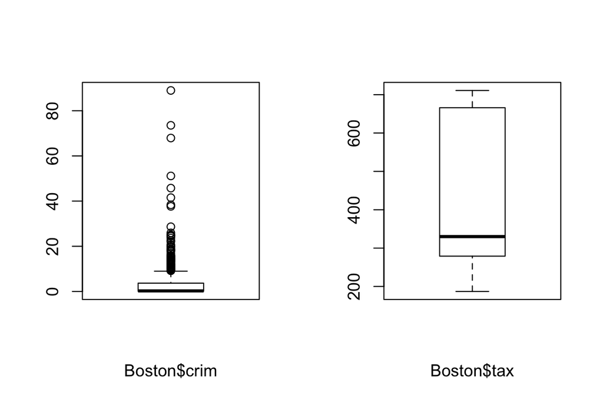

```r
par(mfrow =c(1,2))
boxplot(Boston$crim, xlab="Boston$crim")
boxplot(Boston$tax, xlab="Boston$tax")
```

Let’s change the scaled data into a data frame and create a categorical variable of crime rate using the quantiles as break points.

```r
boston_scaled <- as.data.frame(boston_scaled)
bins <- quantile(boston_scaled$crim)

# We'll label the values of the new variable "low", "med_low", "med_high", and "high"
crime <- cut(boston_scaled$crim, breaks = bins, include.lowest = TRUE, label=c("low", "med_low", "med_high", "high"))
```

Finally, let’s replace the old crime variable in the scaled dataset with this new variable and tabulate its values.

```r
boston_scaled$crim <- crime
table(boston_scaled$crim)
```

```
##
##      low  med_low med_high     high
##      127      126      126      127
```

To evaluate our classification, let’s divide the data into sets used for training and testing the classifier.

```r
library(dplyr)

# Randomly choose 80% of the observations and select these for the training set
n <- nrow(boston_scaled)
ind <- sample(n, size=n * 0.8)
train <- boston_scaled[ind,]

# Use the rest for the test set
test <- boston_scaled[-ind,]
```

Now we’re ready to fit the LDA model to the training data and evaluate it using the test data. Let’s also draw the biplot of the model.

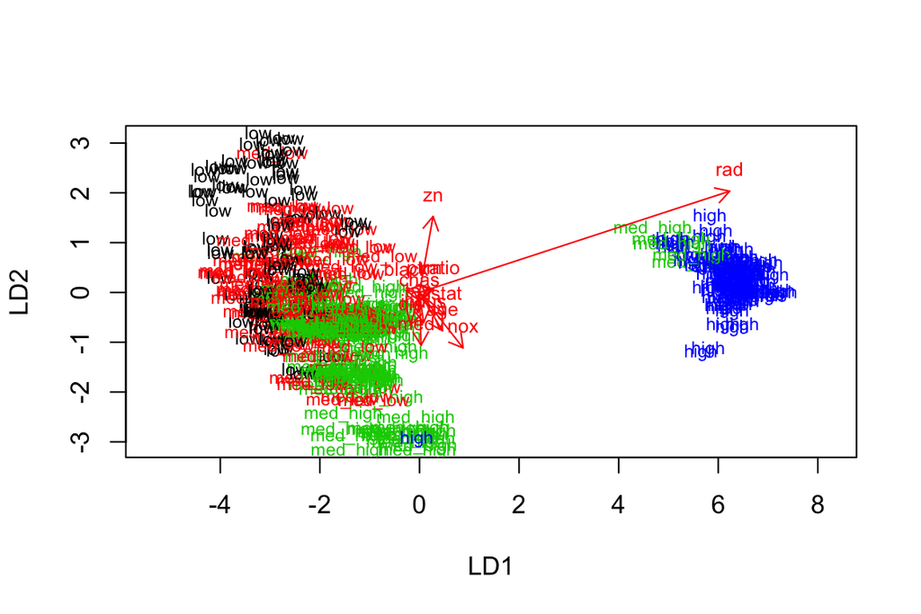

```r
# linear discriminant analysis
lda.fit <- lda(crim ~., data = train)

# the function for lda biplot arrows
lda.arrows <- function(x, myscale = 1, arrow_heads = 0.1, color = "red", tex = 0.75, choices = c(1,2)){
  heads <- coef(x)
  arrows(x0 = 0, y0 = 0,
         x1 = myscale * heads[,choices[1]],
         y1 = myscale * heads[,choices[2]], col=color, length = arrow_heads)
  text(myscale * heads[,choices], labels = row.names(heads),
       cex = tex, col=color, pos=3)
}

# target classes as numeric
classes <- as.numeric(train$crim)

# plot the lda results
plot(lda.fit, dimen = 2, col = classes, pch = classes)
lda.arrows(lda.fit, myscale = 2)
```

From the model results below we can see that the first dimension which separates high values from the rest explains over 94% of the variance in the data (look at the proportion of trace at the end of the summary). The second dimension seems to discriminate between low and med_low and med_high values. However most of the variance in the data seems to be between high values and the rest.

```r
lda.fit
```

```
## Call:
## lda(crim ~ ., data = train)
##
## Prior probabilities of groups:
##       low   med_low  med_high      high
## 0.2599010 0.2450495 0.2425743 0.2524752
##
## Group means:
##                  zn      indus         chas        nox          rm        age
## low       0.9452645 -0.8993731 -0.122344297 -0.8731031  0.45190755 -0.8869731
## med_low  -0.0638826 -0.3328172  0.006051757 -0.6057337 -0.09720949 -0.3927587
## med_high -0.4067362  0.2214227  0.209764839  0.3604156  0.09168099  0.4205266
## high     -0.4872402  1.0171096 -0.079333958  1.0803400 -0.35897590  0.8077365
##                 dis        rad        tax     ptratio      black       lstat
## low       0.8925328 -0.6876449 -0.7539897 -0.46072215  0.3775539 -0.78305237
## med_low   0.3914751 -0.5514861 -0.4892654 -0.07230838  0.3379693 -0.16322342
## med_high -0.3592883 -0.3959186 -0.2883299 -0.25377597  0.1130420 -0.01081729
## high     -0.8337672  1.6382099  1.5141140  0.78087177 -0.9159334  0.95617622
##                 medv
## low       0.53055555
## med_low   0.03783819
## med_high  0.19159201
## high     -0.78802111
##
## Coefficients of linear discriminants:
##                  LD1         LD2         LD3
## zn       0.136606072  0.76312078 -0.93521647
## indus    0.041062459 -0.30339037  0.15982657
## chas     0.001080778 -0.08977959  0.14379558
## nox      0.437965607 -0.55691580 -1.29855852
## rm       0.118435585  0.03534675 -0.04278358
## age      0.230529643 -0.38403796 -0.28703433
## dis     -0.088041175 -0.32624036  0.12446954
## rad      3.114027742  1.01681199 -0.17705733
## tax     -0.016017954 -0.20168366  0.71488983
## ptratio  0.141020557  0.03385636 -0.22165828
## black   -0.130243891  0.01885254  0.14982469
## lstat    0.251668143 -0.22004412  0.47373431
## medv     0.016130126 -0.53131916 -0.26348375
##
## Proportion of trace:
##    LD1    LD2    LD3
## 0.9520 0.0361 0.0119
```

Let’s now test the model on unseen data. First we’ll save the correct categories of the crime variable and remove them from the test data. Then we’ll predict the test data and display a confusion matrix of the results.

```r
correct_classes <- test$crim
test <- dplyr::select(test, -crim)

# predict classes with test data
lda.pred <- predict(lda.fit, newdata = test)

# cross tabulate the results
table(correct = correct_classes, predicted = lda.pred$class)
```

```
##           predicted
## correct    low med_low med_high high
##   low       12      10        0    0
##   med_low    1      18        8    0
##   med_high   1       8       18    1
##   high       0       0        0   25
```

To end this exercise we’ll reload the Boston data to do k-means clustering. We’ll begin by scaling the data again. Let’s also look at a summary of the data to see that everything is ok.

```r
data("Boston")
boston_scaled <- scale(Boston)
summary(boston_scaled)
```

```
##       crim                 zn               indus              chas
##  Min.   :-0.419367   Min.   :-0.48724   Min.   :-1.5563   Min.   :-0.2723
##  1st Qu.:-0.410563   1st Qu.:-0.48724   1st Qu.:-0.8668   1st Qu.:-0.2723
##  Median :-0.390280   Median :-0.48724   Median :-0.2109   Median :-0.2723
##  Mean   : 0.000000   Mean   : 0.00000   Mean   : 0.0000   Mean   : 0.0000
##  3rd Qu.: 0.007389   3rd Qu.: 0.04872   3rd Qu.: 1.0150   3rd Qu.:-0.2723
##  Max.   : 9.924110   Max.   : 3.80047   Max.   : 2.4202   Max.   : 3.6648
##       nox                rm               age               dis
##  Min.   :-1.4644   Min.   :-3.8764   Min.   :-2.3331   Min.   :-1.2658
##  1st Qu.:-0.9121   1st Qu.:-0.5681   1st Qu.:-0.8366   1st Qu.:-0.8049
##  Median :-0.1441   Median :-0.1084   Median : 0.3171   Median :-0.2790
##  Mean   : 0.0000   Mean   : 0.0000   Mean   : 0.0000   Mean   : 0.0000
##  3rd Qu.: 0.5981   3rd Qu.: 0.4823   3rd Qu.: 0.9059   3rd Qu.: 0.6617
##  Max.   : 2.7296   Max.   : 3.5515   Max.   : 1.1164   Max.   : 3.9566
##       rad               tax             ptratio            black
##  Min.   :-0.9819   Min.   :-1.3127   Min.   :-2.7047   Min.   :-3.9033
##  1st Qu.:-0.6373   1st Qu.:-0.7668   1st Qu.:-0.4876   1st Qu.: 0.2049
##  Median :-0.5225   Median :-0.4642   Median : 0.2746   Median : 0.3808
##  Mean   : 0.0000   Mean   : 0.0000   Mean   : 0.0000   Mean   : 0.0000
##  3rd Qu.: 1.6596   3rd Qu.: 1.5294   3rd Qu.: 0.8058   3rd Qu.: 0.4332
##  Max.   : 1.6596   Max.   : 1.7964   Max.   : 1.6372   Max.   : 0.4406
##      lstat              medv
##  Min.   :-1.5296   Min.   :-1.9063
##  1st Qu.:-0.7986   1st Qu.:-0.5989
##  Median :-0.1811   Median :-0.1449
##  Mean   : 0.0000   Mean   : 0.0000
##  3rd Qu.: 0.6024   3rd Qu.: 0.2683
##  Max.   : 3.5453   Max.   : 2.9865
```

Everything seems to be as before, so we can go on. Next we’ll calculate euclidean distances between the observations and run k-means (which by default uses euclidean distances and also does the calculation for us).

Let’s first try with 3 clusters.

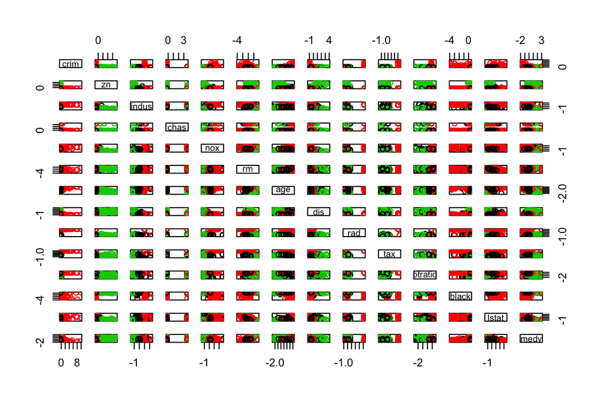

```r
dist_eu <- dist(boston_scaled)
km <-kmeans(boston_scaled, centers = 3)

# plot the Boston dataset with clusters
pairs(boston_scaled, col = km$cluster)
```

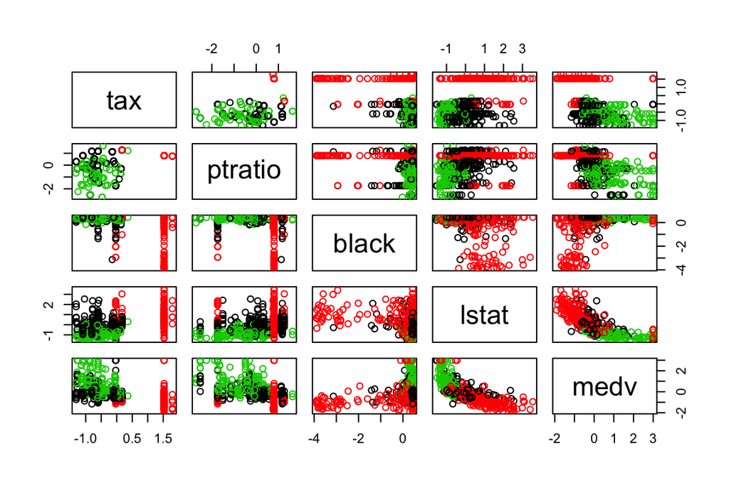

```r
pairs(boston_scaled[,10:14], col = km$cluster)
```

The model seems to capture some clusters of values in the data well. For instance, it correctly clusters high values of the tax variables into one cluster. However, it seems to mix up the low values in two different clusters, although they are pretty closely located together, as can be seen from the plots.

Let’s now investigate what the optimal number of clusters is by checking the elbow plot using the total of within cluster sum of squares as the error measure.

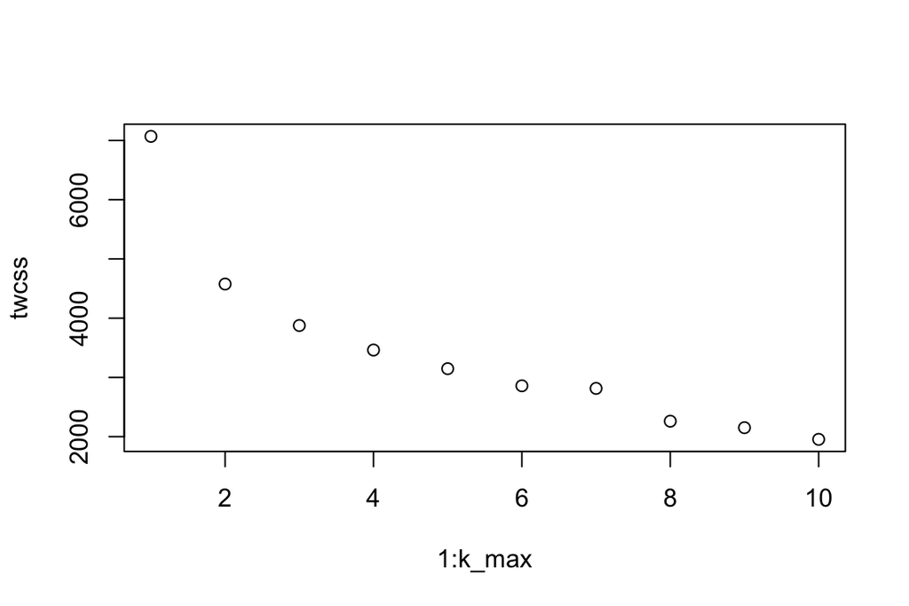

```r
set.seed(123)
k_max <- 10

# calculate the total within sum of squares
twcss <- sapply(1:k_max, function(k){kmeans(boston_scaled, k)$tot.withinss})

# visualize the results
plot(x = 1:k_max, y = twcss)
```

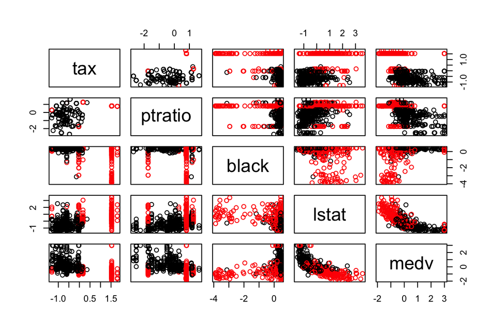

```r
km <-kmeans(boston_scaled, centers = 2)
pairs(boston_scaled[,10:14], col = km$cluster)
```

This model seems to do somewhat better in capturing different clusters of values in the data. For instance, observations with low values of the tax variable are now much more clearly allocated to the same cluster. However, the model still cannot tell apart for instance observations which have low values in black from those that have high values in black. This is might be due to those observations being more clearly separated from each other along some other variable.